[O’Hara on GitHub](https://github.com/oharac)

# Map species stressor intersections

Compiled on Fri Jul 31 18:22:06 2020 by ohara

```r
knitr::opts_chunk$set(fig.width = 6, fig.height = 4, fig.path = 'figs/',
                      echo = TRUE, message = FALSE, warning = FALSE)

library(raster)
source('https://raw.githubusercontent.com/oharac/src/master/R/common.R')

source(here('common_fxns.R'))

dir_str_95vc <- file.path(dir_bd_anx, 'layers/stressors_10km_95vc')
dir_spp_maps <- file.path(dir_bd_anx, 'spp_rasts_mol_2020')
```

# 1 Summary

Maps (.csvs) will be saved for each species in a folder for each stressor. For non-impacted species, a place-holder will be saved, perhaps with `cell_id = NA`.

The matrix method would work well for calculating cumulative impact, but we will skip that for now to enable more resolution at the species and stressor level.

## 1.1 Methods summary

Briefly, the method will loop over each stressor and species; if the species has a non-zero sensitivity to the stressor, the overlap of species range and stressor range will be mapped. If the species is not sensitive, it will still be logged with a placeholder, for process checking…

Note that the intersection cells include only those cells where the species AND stressor are both present in a given year for a given stressor. Range cells outside the stressor area are dropped and are assumed to be unimpacted (refugia); stressor cells outside the range area are dropped and assumed to have no impact on this species.

# 2 Methods

## 2.1 Get the species sensitivities

The species sensitivity dataframe is created in script 1: `1d_combine_spp_stressor_sensitivities.Rmd`. Load this and use it to identify included species and stressors; load the maps file to determine which of these species have range maps as well. Note, the sensitivity file includes non-threatened species, so these will be included in the overall set of intersection maps.

```r
spp_incl_all <- get_incl_spp() %>%
  # filter(!is.na(stressor)) %>% ### make placeholders for non-impacted spp
  select(-code) %>%
  distinct()

spp_ids <- spp_incl_all$iucn_sid %>% unique() %>% sort()

str_names <- spp_incl_all$stressor %>% unique() %>% sort()

spp_str_df <- spp_incl_all %>%
  select(iucn_sid, stressor) %>%
  distinct()


### spp to check for sensitivity to OA and SST: wide-ranging spp sensitive to
### wide-ranging stressors
### 2477, 8005, 22698209, 22694740, 22697870, 22698375, 8153, 13583, 6336
# check_ids <- c(2477, 8005, 22698209, 22694740, 22697870, 22698375, 8153, 13583, 6336)
# check_spp_str <- spp_str_df %>%
#   filter(iucn_sid %in% check_ids)
### none are sensitive to OA; 6336, 8153,   22694740,   22698375 are sensitive to SST

str_w_maps <- list.files(dir_str_95vc) %>%
  str_replace('_[0-9].*', '') %>%
  unique()

if(any(!str_names %in% str_w_maps)) {
  message('NOTE: some listed stressors do not have maps! \n')
}
```

## 2.2 Loop over stressors

Let’s create a function to take a stressor name and use that to pull all the stressor layers (all years) into a raster stack. Let’s also create a function to turn the raster stack into a dataframe of cell IDs and filter to non-NA cells.

```r
build_str_stack <- function(str_name, dir_str = dir_str_95vc) {
  ### str_name <- str_names[1]
  str_rast_files <- list.files(dir_str, pattern = str_name, full.names = TRUE) %>%
    sort()
  years <- str_extract(basename(str_rast_files), '[0-9]{4}')
  str_stack <- raster::stack(str_rast_files)
  names(str_stack) <- sprintf('%s_%s', str_name, years)

  return(str_stack)
}

stack_to_df <- function(str_stack) {
  rast_df_list <- parallel::mclapply(names(str_stack), mc.cores = 20,
    FUN = function(x) {
      ### x <- names(str_stack)[1]
      rast <- str_stack[[x]]
      df <- data.frame(cell_id = 1:ncell(rast),
                       str_val = values(rast)) %>%
        filter(!is.na(str_val)) %>%
        select(-str_val)
      })
  names(rast_df_list) <- names(str_stack)
  rast_df <- bind_rows(rast_df_list, .id = 'str_year') %>%
    mutate(stressor = str_replace(str_year, '_[0-9]{4}', ''),
           year = as.integer(str_extract(str_year, '[0-9]{4}'))) %>%
    select(-str_year)
  return(rast_df)
}

get_spp_map <- function(spp_id) {
  spp_map_file <- file.path(dir_spp_maps,
                            sprintf('iucn_sid_%s.csv', spp_id))
  if(!file.exists(spp_map_file)) {
    stop('Map does not exist: ', basename(spp_map_file))
    # return(NULL)
  }
  spp_map <- read_csv(spp_map_file, col_types = cols(.default = 'i'))
  if(nrow(spp_map) == 0) {
    warning('Species map for ', spp_id, ' is zero length')
  }
  return(spp_map)
}


calc_intsx <- function(spp_id, str_df) {
  spp_map <- get_spp_map(spp_id) %>%
    filter(presence > 0 & !is.na(presence) & presence != 5) %>%
    select(-presence)
  spp_str_intsx <- spp_map %>%
    inner_join(str_df, by = 'cell_id') %>%
    select(-stressor)

  if(nrow(spp_str_intsx) == 0) {
    ### no intersection; warn and create empty df
    message('No intersection found for species ', spp_id, ' and stressor ', str_name)
    spp_str_intsx <- data.frame(
      cell_id = NA,
      year = str_df$year %>% unique())
  }
  return(spp_str_intsx)
}
```

Using this function, loop through each of the included stressors, build the stack, convert to df for easier handling, and then loop over all species to create a map of cell ID and year for all stressor occurrences on the species range. The stressor name will be included in the filename, so no need to include a “stressor” column here… this should save significantly on file size.

```r
reload <- FALSE
### to gut the directory for a fresh start:
# x <- list.files(file.path(dir_bd_anx, 'spp_str_rasts'),
#                 full.names = TRUE, recursive = TRUE)
# unlink(x)

for(str_name in str_names) {
  ### str_name <- str_names[13]
  message('Processing ', str_name)

  dir_spp_str_rast <- file.path(dir_bd_anx, 'spp_str_rasts', str_name)
  if(!dir.exists(dir_spp_str_rast)) {
    dir.create(dir_spp_str_rast)
  }

  str_stack <- build_str_stack(str_name)
  str_df <- stack_to_df(str_stack)

  ### Determine which species are sensitive to this stressor
  spp_str_sens <- spp_str_df %>%
    filter(stressor == str_name)

  ### Stressors with large maps (e.g. OA, SST) take up a lot of memory -
  ### esp if spp also have large maps.  Limit cores such that the
  ### cores * stack_df_size ~ 25% of Mazu memory (119 GB)
  stack_df_size <- object.size(str_df)
  num_cores <- min(as.integer(119e9 / stack_df_size * .25), 16)

  # for(spp_id in spp_ids) {
  tmp <- parallel::mclapply(spp_ids, mc.cores = num_cores,
    FUN = function(spp_id) {
      ### spp_id <- spp_ids[1]
      ### spp_id <- spp_not_done[1]
      # message('species: ', spp_id, '; stressor: ', str_name,
      #         '; calculating spp/str intersection')

      spp_str_file <- file.path(dir_spp_str_rast,
                                sprintf('spp_intsx_%s_%s.csv',
                                        str_name, spp_id))

      if(!file.exists(spp_str_file) | reload) {
        if(spp_id %in% spp_str_sens$iucn_sid) {
          ### species is sensitive; create intersection
          spp_str_intsx <- calc_intsx(spp_id, str_df)
        } else {
          ### species is not sensitive; create dummy intersection
          # message('Spp ', spp_id, ' is not sensitive to ', str_name)
          spp_str_intsx <- data.frame(
            cell_id = NA,
            year = str_df$year %>% unique()
          )
        }
        write_csv(spp_str_intsx, spp_str_file)
      } else {
        # message(basename(spp_str_file), ' exists: skipping!')
      }
      return(TRUE)
    }) ### end of mclapply
  message('For stressor ', str_name, ' found ', sum(unlist(tmp)), ' instances')
}
```

# 3 Check results

Make sure all spp are represented in all stressors (even if an empty csv as a placeholder). Using file size as a proxy for the map size, we can get an impression of how widely distributed the stressor/species interactions are.

```r
spp_mapped <- list.files(file.path(dir_bd_anx, 'spp_str_rasts'),
                         pattern = '.csv',
                         recursive = TRUE, full.names = TRUE)

filesize_mb <- file.size(spp_mapped) / 1e6

chk_df <- data.frame(spp_mapped,
                     filesize_mb) %>%
  mutate(str = dirname(spp_mapped) %>% basename(),
         spp = basename(spp_mapped) %>%
           str_extract('[0-9]+') %>%
           as.integer()) %>%
  group_by(str) %>%
  mutate(n_spp = n_distinct(spp)) %>%
  ungroup()

spp_done <- chk_df %>%
  filter(str == 'art_fish') %>%
  .$spp
spp_not_done <- spp_ids[!spp_ids %in% spp_done]

chk_sum <- chk_df %>%
  select(str, n_spp) %>%
  distinct()

knitr::kable(chk_sum)
```

| str | n_spp |
| --- | --- |
| art_fish | 2645 |
| dem_dest | 2645 |
| dem_nondest_hb | 2645 |
| dem_nondest_lb | 2645 |
| direct_human | 2645 |
| light | 2645 |
| nutrient | 2645 |
| oa | 2645 |
| organic | 2645 |
| pel_hb | 2645 |
| pel_lb | 2645 |
| shipping | 2645 |
| slr | 2645 |
| sst | 2645 |

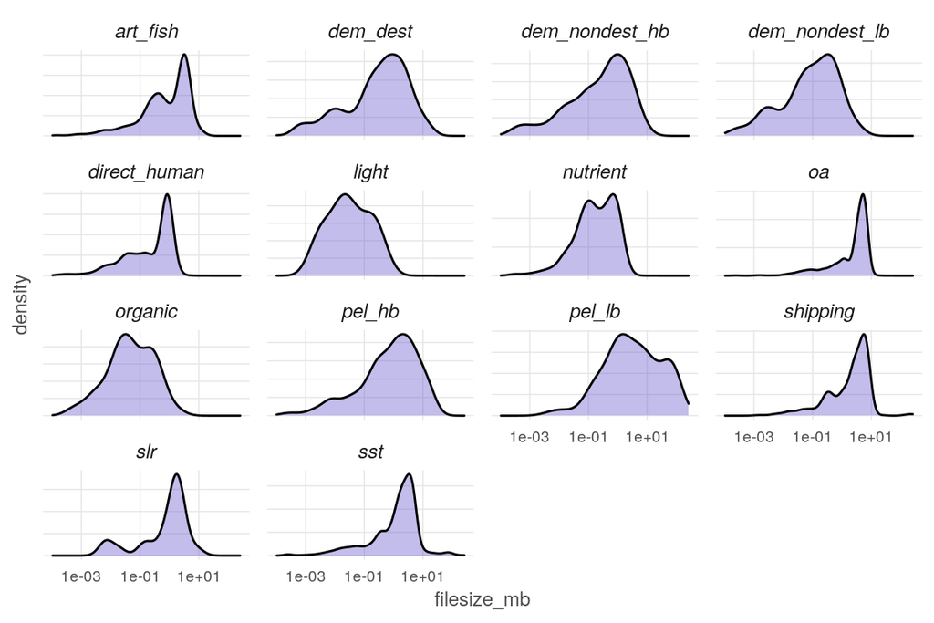

```r
### plot file size densities for each stressor, dropping the
### empty maps (file size 101 B or .000101 MB)
ggplot(chk_df %>% filter(filesize_mb > .000102), aes(x = filesize_mb)) +
  ggtheme_plot() +
  geom_density(fill = 'slateblue', alpha = .4) +
  scale_x_log10() +
  theme(axis.text.y = element_blank()) +
  facet_wrap(~ str, scales = 'free_y')
```